# R Markdown Tutorial

Mustafa Ascha

02 August, 2016

# R Markdown

For more details on authoring Rmarkdown reports, visit:  
http://rmarkdown.rstudio.com/index.html.

1. Motivation
2. Basic Functionality
3. Structure: Preamble, Text, Chunks
4. Text and Formatting
5. Chunks and Inline Code

# Why R Markdown?

[figure not shown]

Presentations!

# Why R Markdown?

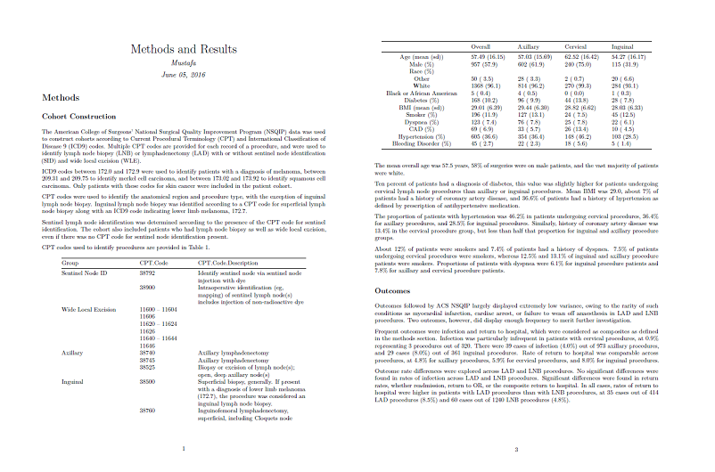

Reports!

# Why R Markdown?

[figure not shown]

Books!

# Dynamic Documents

- Old way: Look at code output, write into document
- New way: Write code, get document

If you find out a patient has a value of 5 instead of 1, you won’t have to go back and rewrite a report: you’ll now have a new report without yourself being an intermediary.

# Basic Functionality

- Open RStudio
- Make a new R Markdown document (select HTML for now)
- Click on “Knit HTML” (install packages first)

[figure not shown]

# Basic Functionality

- See the structure of your document by clicking on the staggered lines button at the top right of your editor

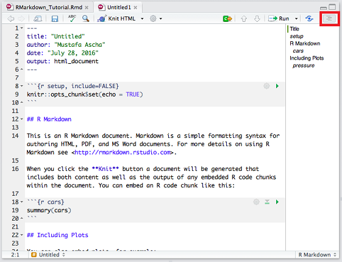

# Structure of a Report

- Preamble: Metadata (like an mp3 has artist, year, song title)

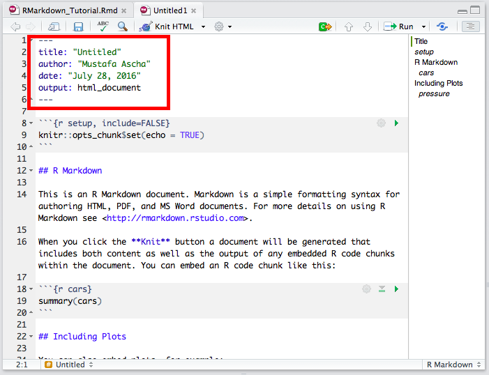

# Structure of a Report

- Preamble: Metadata (like an mp3 has artist, year, song title)
- Text: Where you put your commentary and thoughts

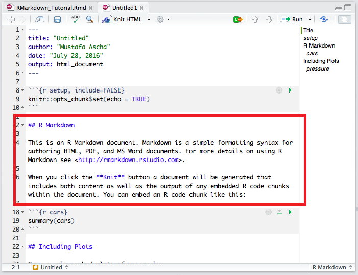

# Structure of a Report

- Preamble: Metadata (like an mp3 has artist, year, song title)
- Text: Where you put your commentary and thoughts
- Chunks: Where you put code that you can explain using text

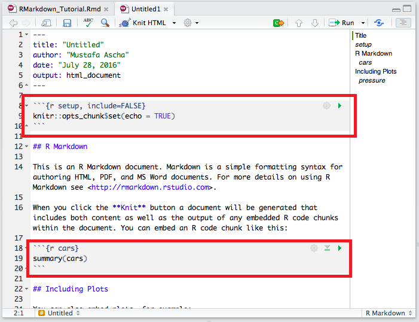

# The Preamble

- This is where you specify things **about** your document, such as author, general format, or font color.
- For now, mostly use the defaults.
- Find more options [here](http://rmarkdown.rstudio.com/pdf_document_format.html) or [here](http://rmarkdown.rstudio.com/authoring_pandoc_markdown.html#yaml-metadata-block)

Here’s an example:

```r
---
title:  'This is the title: \n it contains a colon and new line'
subtitle: 'This is a really short subtitle'
author:
- Author One
- Author Two
date: "`r format(Sys.time(), '%d %B %Y')`"
output:
    html_document:
        template: NULL
---
```

# The Preamble: Table of contents

- Outline on the right of your text editor
- Table of contents in the text.

```r
---
title:  'This is the title: \n it contains a colon and new line'
subtitle: 'This is a really short subtitle'
author:
- Author One
- Author Two
date: "`r format(Sys.time(), '%d %B %Y')`"
output:
    html_document:
        toc: true
        template: NULL
---
```

# Text and Formatting

- Lots of options

# Text and Formatting

- Lots of options
- See help! (There’s lots of help)

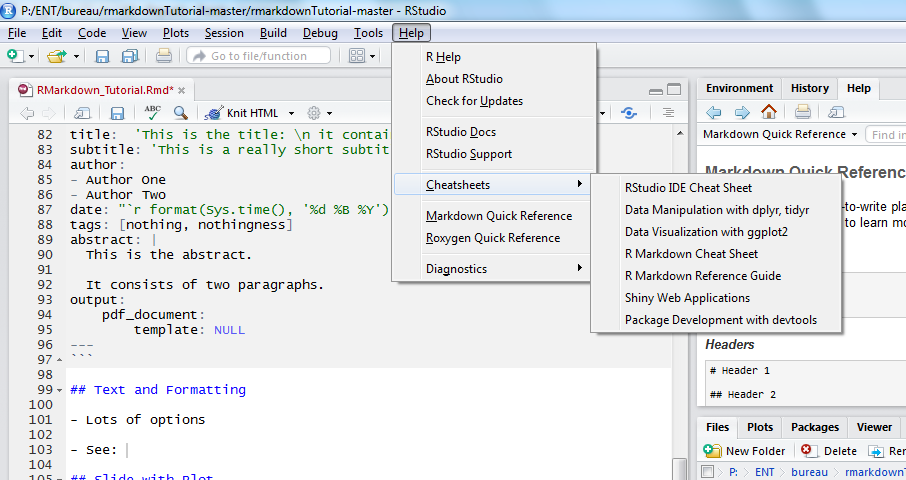

# Text and Formatting: Text

- *Italicize* using a single star: `*italics*`
- Make text **bold** by surrounding it with two asterisks: `**bold**`
- Add links by using brackets then parentheses: `[something something text](http://link.com)`

# Text and Formatting: Breaks

- If you want a new line, add two spaces to the end of your previous line
- Force RMarkdown to start a new page using `\pagebreak`
- Horizontal ruler and pagebreak: use 3 or more dashes or asterisks:
- `----` or `****`

# Text and Formatting: Long quotes

- If you have a long quote, precede each line with `>`

> Roses are red  
> Violets are blue  
> RMarkdown is cool  
> And so are you!

# Text and Formatting: Headers

- Headers organize your document

# Text and Formatting: Headers

- Headers organize your document
- “Header 1” adds a new section to your document Add a header 1 using `#`

# Text and Formatting: Headers

- Headers organize your document
- “Header 1” adds a new section to your document Add a header 1 using `#`
- “Header 2” refers to a sub-header, kind of like a sub-section

# Text and Formatting: Headers

- Headers organize your document
- “Header 1” adds a new section to your document Add a header 1 using `#`
- “Header 2” refers to a sub-header, kind of like a sub-section Add a header 2 using `##`
- Add header 3 or 4 using `###` or `####`

# Text and Formatting: Headers

- Headers organize your document
- “Header 1” adds a new section to your document Add a header 1 using `#`
- “Header 2” refers to a sub-header, kind of like a sub-section Add a header 2 using `##`
- Add header 3 or 4 using `###` or `####`
- Your table of contents and document outline automatically update! Try it!!

# Text and Formatting: Inline code

- Add code output to your text by wrapping the code with backticks

This:

[figure not shown]

# Text and Formatting: Inline code

- Add code output to your text by wrapping the code with backticks

This:

[figure not shown]

Becomes this:

The mean `mpg` in the `mtcars` data is 20.090625.

# Text and Formatting: Making inline code prettier

The mean `mpg` in the `mtcars` data is 20.09.

# Text and Formatting: Making inline code even prettier

- Sometimes you want even more control over the display of your numbers.
- In this case, use `sprintf`

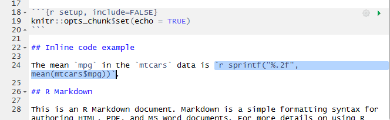

Becomes:

The mean `mpg` in the `mtcars` data is 20.09.

# Text and Formatting: Tables

- There are a few different ways, depending on formatting

# Text and Formatting: Tables, simple

This is a simple table, with one line per row:

```r
  Right     Left     Center     Default
-------     ------ ----------   -------
     12     12        12            12
    123     123       123          123
      1     1          1             1

Table:  Demonstration of simple table syntax.
```

Notice where the cells’ text is placed with respect to the hyphens above it.

[Taken from the RStudio website.](http://rmarkdown.rstudio.com/authoring_pandoc_markdown.html#tables)

# Text and Formatting: Tables, simple

Becomes:

Demonstration of simple table syntax.

| Right | Left | Center | Default |
| --- | --- | --- | --- |
| 12 | 12 | 12 | 12 |
| 123 | 123 | 123 | 123 |
| 1 | 1 | 1 | 1 |

Notice that the text is justified in the same way that it is coded.

[Taken from the RStudio website.](http://rmarkdown.rstudio.com/authoring_pandoc_markdown.html#tables)

# Text and Formatting: Tables, multiline

- Sometimes you need more than one line in a row
- Use a multiline table:

```r
-------------------------------------------------------------
 Centered   Default           Right Left
  Header    Aligned         Aligned Aligned
----------- ------- --------------- -------------------------
   First    row                12.0 Example of a row that
                                    spans multiple lines.

  Second    row                 5.0 Here's another one. Note
                                    the blank line between
                                    rows.
-------------------------------------------------------------

Table: Here's the caption. It, too, may span
multiple lines.
```

Again, notice where the cells’ text is placed with respect to the hyphens above it.

[Again, taken from the RStudio website.](http://rmarkdown.rstudio.com/authoring_pandoc_markdown.html#tables)

# Text and Formatting: Tables, multiline

- Sometimes you need more than one line in a row
- Use a multiline table:

Here’s the caption. It, too, may span multiple lines.

| Centered Header | Default Aligned | Right Aligned | Left Aligned |
| --- | --- | --- | --- |
| First | row | 12.0 | Example of a row that spans multiple lines. |
| Second | row | 5.0 | Here’s another one. Note the blank line between rows. |

Again, the text is formatted the same way it is coded.

[Again, taken from the RStudio website.](http://rmarkdown.rstudio.com/authoring_pandoc_markdown.html#tables)

# R Chunks

- R chunks are snippets of code that you can add to your report
- Automated report generation - rather than rewrite everything, click “knit”

Here’s what a chunk looks like:

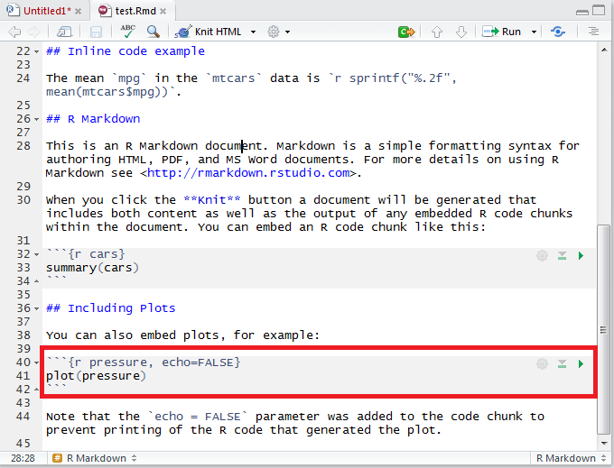

# R Chunks: Structure

- Indicate the start of a chunk with three backticks and a chunk preamble

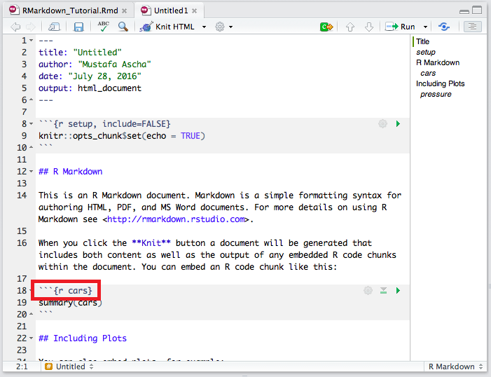

# R Chunks: Structure

- Indicate the end of a chunk with three backticks

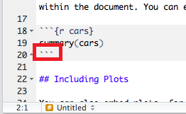

# R Chunks: Structure

- They have names
- Names **must** be unique

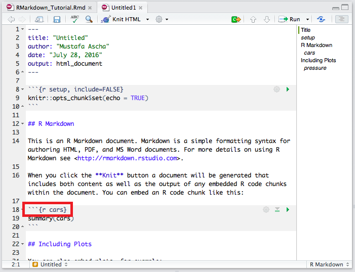

# R Chunks: Structure

- Names are included in your outline

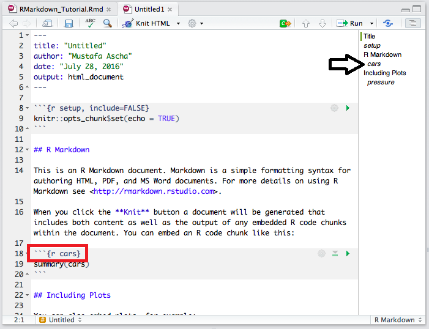

# R Chunks: Structure

- Names are included in your outline
- Name them well so you can stay organized
- Organization helps you find what you need in code, too!

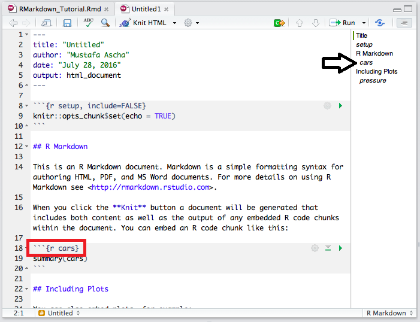

# R Chunks: Behavior

When you compile your document, the chunk will show code output.

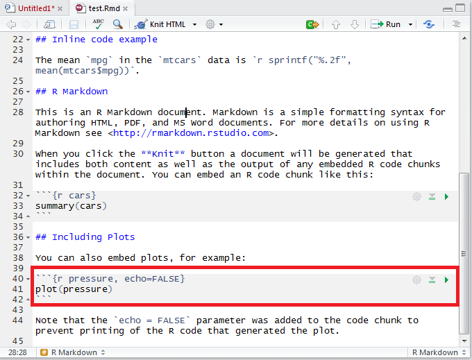

# R Chunks: Behavior

When you compile your document, the chunk will show code output.

This:

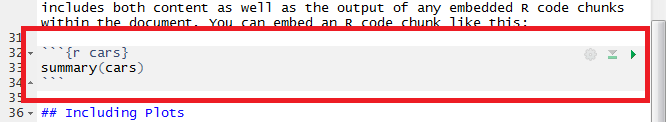

# R Chunks: Behavior

Becomes:

```
##      speed           dist
##  Min.   : 4.0   Min.   :  2.00
##  1st Qu.:12.0   1st Qu.: 26.00
##  Median :15.0   Median : 36.00
##  Mean   :15.4   Mean   : 42.98
##  3rd Qu.:19.0   3rd Qu.: 56.00
##  Max.   :25.0   Max.   :120.00
```

# R Chunks: Options

- You can set various options for your chunk
- Three options to know right now: `echo`, `message`, and `warning`

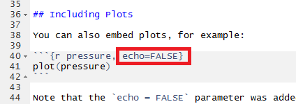

# R Chunks: Options

# R Chunks: Options

# R Chunks: Options

# R Chunks: Options

- Besides setting options for a specific chunk, you can also set chunk options for the entire document:

```r
knitr::opts_chunk$set(echo = FALSE, message = FALSE, warning = FALSE)
```

The previous options would show *only* code output.

# R Chunks: Make things pretty with pander

- Install the `pander` library with `install.packages`

```r
#install.packages("pander")

library(pander)
```

# R Chunks: Make things pretty with pander

- `pander` is a function (and a library) that makes your code output pretty.
- You can give `pander` lots of diffent types of objects, such as dataframes or models

This:

```r
mtcarsHead <- head(mtcars, n = 4)

mtcarsHead
```

```
##                 mpg cyl disp  hp drat    wt  qsec vs am gear carb
## Mazda RX4      21.0   6  160 110 3.90 2.620 16.46  0  1    4    4
## Mazda RX4 Wag  21.0   6  160 110 3.90 2.875 17.02  0  1    4    4
## Datsun 710     22.8   4  108  93 3.85 2.320 18.61  1  1    4    1
## Hornet 4 Drive 21.4   6  258 110 3.08 3.215 19.44  1  0    3    1
```

# R Chunks: Make things pretty with pander

- `pander` is a function (and a library) that makes your code output pretty.
- You can give `pander` lots of diffent types of objects, such as dataframes or models

Becomes:

```r
pander(mtcarsHead)
```

|  | mpg | cyl | disp | hp | drat | wt | qsec | vs | am | gear | carb |
| --- | --- | --- | --- | --- | --- | --- | --- | --- | --- | --- | --- |
| **Mazda RX4** | 21 | 6 | 160 | 110 | 3.9 | 2.62 | 16.46 | 0 | 1 | 4 | 4 |
| **Mazda RX4 Wag** | 21 | 6 | 160 | 110 | 3.9 | 2.875 | 17.02 | 0 | 1 | 4 | 4 |
| **Datsun 710** | 22.8 | 4 | 108 | 93 | 3.85 | 2.32 | 18.61 | 1 | 1 | 4 | 1 |
| **Hornet 4 Drive** | 21.4 | 6 | 258 | 110 | 3.08 | 3.215 | 19.44 | 1 | 0 | 3 | 1 |

# R Chunks: Make things pretty with pander

- You can even give pander output from other functions!

```r
pander(summary(cars))
```

| speed | dist |
| --- | --- |
| Min. : 4.0 | Min. : 2.00 |
| 1st Qu.:12.0 | 1st Qu.: 26.00 |
| Median :15.0 | Median : 36.00 |
| Mean :15.4 | Mean : 42.98 |
| 3rd Qu.:19.0 | 3rd Qu.: 56.00 |
| Max. :25.0 | Max. :120.00 |

# Future directions

- Citations
- Animated reports
- Interactive reports
- Presentations
- Books

# Conclusions

- R Markdown makes research easier
- Lots of people have done lots of thinking about R Markdown, so you can find more information about it online

# Conclusions

- Thanks for not sleeping!